# The Impact of Maternal Sociodemographic Factors on Prenatal Care

# 4.1 ANOVA: Birthweight by Prenatal Care Start

We use **one-way ANOVA** because: - The predictor (**prenatal care start**) is categorical (4 groups) - The outcome (**birthweight**) is continuous - We are comparing the means across multiple groups

Before running ANOVA, we check assumptions and exclude missing values only for relevant variables.

## 4.1.1 Prepare Data for ANOVA

```r
# Exclude observations with missing birthweight or prenatal care start
anova_data <- natality_all %>%
  filter(!is.na(prenatal_care_start), !is.na(birthweight_grams))
```

## 4.1.2 Check Assumption: Normality of Outcome

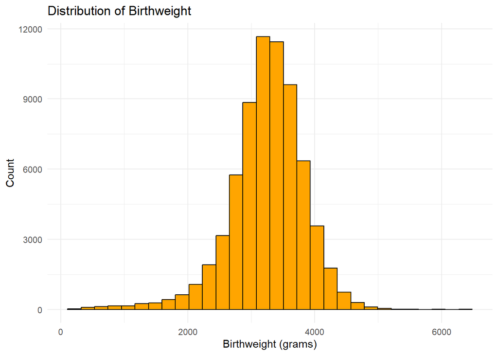

```r
# Assumption to check birthweight distribution
ggplot(anova_data, aes(x = birthweight_grams)) +
  geom_histogram(color = "black", fill = "orange", bins = 30) +
  labs(title = "Distribution of Birthweight", x = "Birthweight (grams)", y = "Count") +
  theme_minimal()
```

### Interpretation: The visualization for birthweight distribution we got is symmetrical or bell-shaped. The normality assumption for ANOVA is reasonably satisfied.

## 4.1.3 Check Assumption: Homogeneity of Variances

```r
# Levene's Test for homogeneity of variances
leveneTest(birthweight_grams ~ prenatal_care_start, data = anova_data)
```

|  | Df | F value | Pr(>F) |
| --- | --- | --- | --- |
| group | 3 | 38.96936 | 3.754653e-25 |
|  | 68391 | NA | NA |

### Interpretation:

Although Levene’s Test indicated unequal variances (p < 0.001), regular one-way ANOVA was conducted because Welch’s ANOVA was not covered in course material. Results should be interpreted with caution.

## 4.1.4 Perform One-Way ANOVA

We now perform regular **one-way ANOVA** to determine whether there are statistically significant differences in **birthweight** across **prenatal care initiation groups**.

Although Levene’s Test indicated unequal variances, we proceed with regular ANOVA because Welch’s ANOVA was not covered in the course material. Results should be interpreted with caution.

```r
# Perform regular one-way ANOVA
anova_result <- aov(birthweight_grams ~ prenatal_care_start, data = anova_data)

# Display ANOVA table
summary(anova_result)
```

```
##                        Df    Sum Sq  Mean Sq F value Pr(>F)
## prenatal_care_start     3 9.391e+07 31304316   92.13 <2e-16 ***
## Residuals           68391 2.324e+10   339768
## ---
## Signif. codes:  0 '***' 0.001 '**' 0.01 '*' 0.05 '.' 0.1 ' ' 1
```